# Project: tmdb movies data analysis

- Introduction
- Data Wrangling
- Exploratory Data Analysis
- Conclusions

## Introduction

In this project, we will explore the tmdb movies data, containing information about over 10 thousands movies from 1960 to 2015. We will be interested in finding trends associated with the movies that have the more success and how they differ from the movies with less success. In the end, the questions we ll answer here are:

- What movies genre make the more profit?
- What movie duration generates the more profit?
- What release months are more profitable?
- Does the average grade of a movie predicts its profitability?

```python
# Import statements for packages
import pandas as pd
import numpy as np
import matplotlib.pyplot as plt
% matplotlib inline
```

## Data Wrangling

### General Properties

```python
df = pd.read_csv('tmdb-movies.csv')
df.head(2)
```

|  | id | imdb_id | popularity | budget | revenue | original_title | cast | homepage | director | tagline | ... | overview | runtime | genres | production_companies | release_date | vote_count | vote_average | release_year | budget_adj | revenue_adj |
| --- | --- | --- | --- | --- | --- | --- | --- | --- | --- | --- | --- | --- | --- | --- | --- | --- | --- | --- | --- | --- | --- |
| 0 | 135397 | tt0369610 | 32.985763 | 150000000.0 | 1.513529e+09 | Jurassic World | Chris Pratt\|Bryce Dallas Howard\|Irrfan Khan\|Vi... | http://www.jurassicworld.com/ | Colin Trevorrow | The park is open. | ... | Twenty-two years after the events of Jurassic ... | 124.0 | Action\|Adventure\|Science Fiction\|Thriller | Universal Studios\|Amblin Entertainment\|Legenda... | 6/9/15 | 5562.0 | 6.5 | 2015.0 | 1.379999e+08 | 1.392446e+09 |
| 1 | 76341 | tt1392190 | 28.419936 | 150000000.0 | 3.784364e+08 | Mad Max: Fury Road | Tom Hardy\|Charlize Theron\|Hugh Keays-Byrne\|Nic... | http://www.madmaxmovie.com/ | George Miller | What a Lovely Day. | ... | An apocalyptic story set in the furthest reach... | 120.0 | Action\|Adventure\|Science Fiction\|Thriller | Village Roadshow Pictures\|Kennedy Miller Produ... | 5/13/15 | 6185.0 | 7.1 | 2015.0 | 1.379999e+08 | 3.481613e+08 |

2 rows × 21 columns

```python
df.shape
```

```
(10866, 21)
```

So we have data for more than 10 thousand movies, over 21 columns.

```python
df.describe()
```

|  | popularity | budget | revenue | runtime | vote_count | vote_average | release_year | budget_adj | revenue_adj |
| --- | --- | --- | --- | --- | --- | --- | --- | --- | --- |
| count | 10863.000000 | 1.086300e+04 | 1.086300e+04 | 10863.000000 | 10863.000000 | 10863.000000 | 10863.000000 | 1.086300e+04 | 1.086300e+04 |
| mean | 0.646555 | 1.462935e+07 | 3.983430e+07 | 102.072356 | 217.446009 | 5.975292 | 2001.319893 | 1.755551e+07 | 5.137854e+07 |
| std | 1.000296 | 3.091668e+07 | 1.170178e+08 | 31.385222 | 575.688581 | 0.934906 | 12.813584 | 3.430982e+07 | 1.446499e+08 |
| min | 0.000065 | 0.000000e+00 | 0.000000e+00 | 0.000000 | 10.000000 | 1.500000 | 1960.000000 | 0.000000e+00 | 0.000000e+00 |
| 25% | 0.207637 | 0.000000e+00 | 0.000000e+00 | 90.000000 | 17.000000 | 5.400000 | 1995.000000 | 0.000000e+00 | 0.000000e+00 |
| 50% | 0.383880 | 0.000000e+00 | 0.000000e+00 | 99.000000 | 38.000000 | 6.000000 | 2006.000000 | 0.000000e+00 | 0.000000e+00 |
| 75% | 0.713994 | 1.500000e+07 | 2.400366e+07 | 111.000000 | 146.000000 | 6.600000 | 2011.000000 | 2.085325e+07 | 3.371677e+07 |
| max | 32.985763 | 4.250000e+08 | 2.781506e+09 | 900.000000 | 9767.000000 | 9.200000 | 2015.000000 | 4.250000e+08 | 2.827124e+09 |

```python
type(df['release_date'][0])
```

```
str
```

Will need to turn release_date data type to date.

```python
df.duplicated().sum()
```

```
1
```

We have only 1 duplicate row in the dataset, we'll remove it in the next part.

```python
df.isnull().sum()
```

```
id                                    0
imdb_id                              13
popularity                            3
budget                                3
revenue                               3
original_title                        3
cast                                 79
homepage                           7933
director                             47
tagline                            2826
keywords                           1495
overview                              7
runtime                               3
genres                               26
production_companies               1032
release_date                          3
vote_count                            3
vote_average                          3
release_year                          3
budget_adj                            3
revenue_adj\t\t\t\t\t\t\t\t\t\t       3
dtype: int64
```

We are the more interested in vote average, adjusted budget and revenue, for those we have 3 rows with null values, we'll cope with it.

### Data Cleaning

In this section we will perform some cleanning:

- Fix column name: 'revenue_adj\t\t\t\t\t\t\t\t\t\t'
- Remove few columns not useful for this analysis (budget, revenue, homepage, tagline, keywords and overview)
- Among budget_adj, revenue_adj and runtime columns, many contain values of 0 -> filling with the average of each column.
- Remove the duplicate
- Release_date data type: from string to date

Rename revenue adj:

```python
df = df.rename(columns = {'revenue_adj\t\t\t\t\t\t\t\t\t\t': 'revenue_adj'})
df.columns
```

```
Index(['id', 'imdb_id', 'popularity', 'budget', 'revenue', 'original_title',
       'cast', 'homepage', 'director', 'tagline', 'keywords', 'overview',
       'runtime', 'genres', 'production_companies', 'release_date',
       'vote_count', 'vote_average', 'release_year', 'budget_adj',
       'revenue_adj'],
      dtype='object')
```

Drop unecessary columns:

```python
df.drop(['budget','revenue','homepage','tagline','keywords','overview', 'production_companies'], axis=1, inplace=True)
df.columns
```

```
Index(['id', 'imdb_id', 'popularity', 'original_title', 'cast', 'director',
       'runtime', 'genres', 'release_date', 'vote_count', 'vote_average',
       'release_year', 'budget_adj', 'revenue_adj'],
      dtype='object')
```

Remove the duplicate:

```python
df = df[df.duplicated() == False]
```

Turn release_date to date:

```python
df['release_date'] = pd.to_datetime(df['release_date'])
df.dtypes
```

```
id                        object
imdb_id                   object
popularity               float64
original_title            object
cast                      object
director                  object
runtime                  float64
genres                    object
release_date      datetime64[ns]
vote_count               float64
vote_average             float64
release_year             float64
budget_adj               float64
revenue_adj              float64
dtype: object
```

Add to 0 runtime, adj budget and revenue the value of the average of each group:

```python
#get the means values:

mean_runtime = df['runtime'].mean()
mean_budget = df['budget_adj'].mean()
mean_revenue = df['revenue_adj'].mean()
```

```python
#replace the 0 with the means value:

df['runtime'] = df['runtime'].replace(0,mean_runtime)
df['budget_adj'] = df['budget_adj'].replace(0,mean_budget)
df['revenue_adj'] = df['revenue_adj'].replace(0,mean_revenue)
```

```python
#check:
df.describe()
```

|  | popularity | runtime | vote_count | vote_average | release_year | budget_adj | revenue_adj |
| --- | --- | --- | --- | --- | --- | --- | --- |
| count | 10862.000000 | 10862.000000 | 10862.000000 | 10862.000000 | 10862.000000 | 1.086200e+04 | 1.086200e+04 |
| mean | 0.646559 | 102.364599 | 217.455901 | 5.975382 | 2001.319094 | 2.675659e+07 | 7.983267e+07 |
| std | 1.000342 | 30.907771 | 575.714160 | 0.934902 | 12.813903 | 3.051254e+07 | 1.365792e+08 |
| min | 0.000065 | 2.000000 | 10.000000 | 1.500000 | 1960.000000 | 9.210911e-01 | 2.370705e+00 |
| 25% | 0.207621 | 90.000000 | 17.000000 | 5.400000 | 1995.000000 | 1.755437e+07 | 5.138318e+07 |
| 50% | 0.383856 | 99.000000 | 38.000000 | 6.000000 | 2006.000000 | 1.755437e+07 | 5.138318e+07 |
| 75% | 0.714063 | 111.000000 | 146.000000 | 6.600000 | 2011.000000 | 2.085325e+07 | 5.138318e+07 |
| max | 32.985763 | 900.000000 | 9767.000000 | 9.200000 | 2015.000000 | 4.250000e+08 | 2.827124e+09 |

## Exploratory Data Analysis

### What genres make the more profit?

```python
#Create a column for each genre of the list in column 'genres', extracting  using split on the separator "|"

df_genres = df.copy()

def split_genre(column_num):
    df_genres['genre_{}'.format(column_num)] = df_genres['genres'].str.split("|", expand=True)[column_num-1]

for n in range(1,6):
    split_genre(n)

#df_genres['genre_1'] = df_genres['genres'].str.split("|", expand=True)[0]
#df_genres['genre_2'] = df_genres['genres'].str.split("|", expand=True)[1]
#df_genres['genre_3'] = df_genres['genres'].str.split("|", expand=True)[2]
#df_genres['genre_4'] = df_genres['genres'].str.split("|", expand=True)[3]
#df_genres['genre_5'] = df_genres['genres'].str.split("|", expand=True)[4]
```

```python
#Check
df_genres.head(2)
```

|  | id | imdb_id | popularity | original_title | cast | director | runtime | genres | release_date | vote_count | vote_average | release_year | budget_adj | revenue_adj | genre_1 | genre_2 | genre_3 | genre_4 | genre_5 |
| --- | --- | --- | --- | --- | --- | --- | --- | --- | --- | --- | --- | --- | --- | --- | --- | --- | --- | --- | --- |
| 0 | 135397 | tt0369610 | 32.985763 | Jurassic World | Chris Pratt\|Bryce Dallas Howard\|Irrfan Khan\|Vi... | Colin Trevorrow | 124.0 | Action\|Adventure\|Science Fiction\|Thriller | 2015-06-09 | 5562.0 | 6.5 | 2015.0 | 1.379999e+08 | 1.392446e+09 | Action | Adventure | Science Fiction | Thriller | None |
| 1 | 76341 | tt1392190 | 28.419936 | Mad Max: Fury Road | Tom Hardy\|Charlize Theron\|Hugh Keays-Byrne\|Nic... | George Miller | 120.0 | Action\|Adventure\|Science Fiction\|Thriller | 2015-05-13 | 6185.0 | 7.1 | 2015.0 | 1.379999e+08 | 3.481613e+08 | Action | Adventure | Science Fiction | Thriller | None |

```python
#Now we can remove the original genre column from the dataframe

df_genres.drop('genres', axis=1, inplace=True)
```

```python
#Add profit column
#Here I chose to use the 'percentage' of profit of the movie ie revenue generated compared to the budget spent

df_genres['profit_perc'] = (df['revenue_adj'] - df['budget_adj']) / df['budget_adj']
df_genres.head(2)
```

|  | id | imdb_id | popularity | original_title | cast | director | runtime | release_date | vote_count | vote_average | release_year | budget_adj | revenue_adj | genre_1 | genre_2 | genre_3 | genre_4 | genre_5 | profit_perc |
| --- | --- | --- | --- | --- | --- | --- | --- | --- | --- | --- | --- | --- | --- | --- | --- | --- | --- | --- | --- |
| 0 | 135397 | tt0369610 | 32.985763 | Jurassic World | Chris Pratt\|Bryce Dallas Howard\|Irrfan Khan\|Vi... | Colin Trevorrow | 124.0 | 2015-06-09 | 5562.0 | 6.5 | 2015.0 | 1.379999e+08 | 1.392446e+09 | Action | Adventure | Science Fiction | Thriller | None | 9.090192 |
| 1 | 76341 | tt1392190 | 28.419936 | Mad Max: Fury Road | Tom Hardy\|Charlize Theron\|Hugh Keays-Byrne\|Nic... | George Miller | 120.0 | 2015-05-13 | 6185.0 | 7.1 | 2015.0 | 1.379999e+08 | 3.481613e+08 | Action | Adventure | Science Fiction | Thriller | None | 1.522909 |

```python
#let's focus on the 10 highest profits

df_top = df_genres.nlargest(10, 'profit_perc')
```

```python
#Keep only the genres columns to perform easily the count of appearances of each genre in the top 10

df_top.drop(['id','imdb_id' ,'cast','director', 'popularity','runtime','revenue_adj','release_date'], axis=1, inplace=True)
df_top.drop(['vote_count','vote_average','release_year','budget_adj', 'profit_perc','original_title'], axis=1, inplace=True)
df_top.head(3)
```

|  | genre_1 | genre_2 | genre_3 | genre_4 | genre_5 |
| --- | --- | --- | --- | --- | --- |
| 1151 | Horror | None | None | None | None |
| 3065 | Comedy | Drama | Family | Romance | None |
| 3765 | Animation | Drama | None | None | None |

```python
#From this top 10 let's count what genres appear the more
#To count the number of appearance of each genre, first will turn the 5 genre columns to rows,
#so the info will be reachable in a single column, easier to manipulate.
#To do that, found that melt() will help

df_top_step1 = df_top.melt()
df_top_step1.head()
```

|  | variable | value |
| --- | --- | --- |
| 0 | genre_1 | Horror |
| 1 | genre_1 | Comedy |
| 2 | genre_1 | Animation |
| 3 | genre_1 | Comedy |
| 4 | genre_1 | Drama |

```python
#Now using groupby we can count how many times each genre appear in our top 10 movies

df_top_step2 = df_top_step1.groupby('value').count()
df_top_step2
```

| value | variable |
| --- | --- |
| Action | 2 |
| Adventure | 1 |
| Animation | 1 |
| Comedy | 5 |
| Crime | 2 |
| Drama | 7 |
| Family | 1 |
| History | 1 |
| Horror | 1 |
| Romance | 1 |
| Thriller | 2 |
| War | 1 |

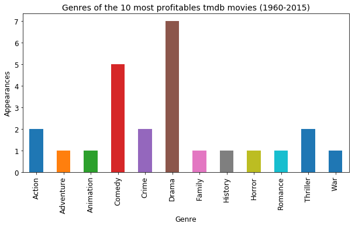

```python
#Finally we can illustrate the relusts found in a bar chart

df_top_step2['variable'].plot(kind="bar", figsize=(10,5), fontsize=12)
plt.xlabel('Genre', fontsize = 12)
plt.ylabel('Appearances', fontsize = 12)
plt.title('Genres of the 10 most profitables tmdb movies (1960-2015)', fontsize = 14);
```

The genres that get the higher profits compared to the budget they invested are Comedy and Drama. Makes sence as they require less money than adventure or science fiction that need a lot of effects, technology and sets to succeed.

### What runtimes are more profitable?

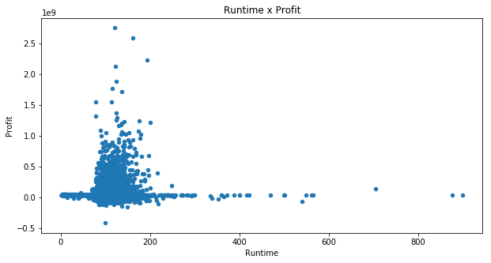

```python
# Let's try to see direclty the relationship graphically

df['profit'] =  df['revenue_adj'] - df['budget_adj']
df.plot(x='runtime', y='profit', kind='scatter', figsize=(10,5))
plt.title('Runtime x Profit')
plt.xlabel('Runtime')
plt.ylabel('Profit');
```

### What release months are more profitable?

```python
#lets exctract the month from the release_date and create a new column
df['release_month'] = df['release_date'].apply(lambda x: x.month)
df.head(2)
```

|  | id | imdb_id | popularity | original_title | cast | director | runtime | genres | release_date | vote_count | vote_average | release_year | budget_adj | revenue_adj | profit | release_month |
| --- | --- | --- | --- | --- | --- | --- | --- | --- | --- | --- | --- | --- | --- | --- | --- | --- |
| 0 | 135397 | tt0369610 | 32.985763 | Jurassic World | Chris Pratt\|Bryce Dallas Howard\|Irrfan Khan\|Vi... | Colin Trevorrow | 124.0 | Action\|Adventure\|Science Fiction\|Thriller | 2015-06-09 | 5562.0 | 6.5 | 2015.0 | 1.379999e+08 | 1.392446e+09 | 1.254446e+09 | 6.0 |
| 1 | 76341 | tt1392190 | 28.419936 | Mad Max: Fury Road | Tom Hardy\|Charlize Theron\|Hugh Keays-Byrne\|Nic... | George Miller | 120.0 | Action\|Adventure\|Science Fiction\|Thriller | 2015-05-13 | 6185.0 | 7.1 | 2015.0 | 1.379999e+08 | 3.481613e+08 | 2.101614e+08 | 5.0 |

```python
#Here I chose to use the percentage of profit of the movie ie revenue generated compared to the budget spent

df['profit_perc'] =  (df['revenue_adj'] - df['budget_adj'])/df['budget_adj']
```

```python
#Now we can group the movies by release month and sum the revenue

monthly_profits = df.groupby('release_month')['profit_perc'].sum()
monthly_profits
```

```
release_month
1.0     1.217608e+06
2.0     4.769017e+05
3.0     3.115205e+06
4.0     5.650488e+06
5.0     3.145409e+07
6.0     1.590846e+06
7.0     5.983797e+07
8.0     1.744714e+07
9.0     4.336586e+06
10.0    6.265546e+07
11.0    1.896871e+04
12.0    9.396353e+06
Name: profit_perc, dtype: float64
```

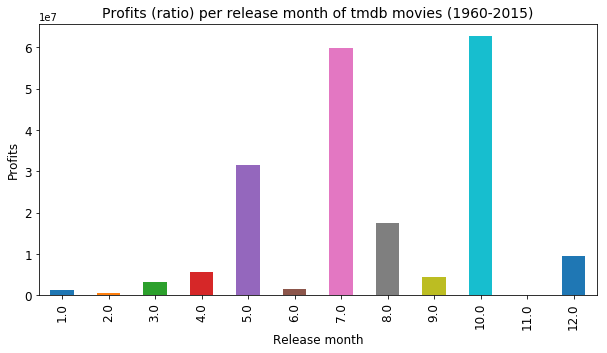

```python
monthly_profits.plot(kind="bar", figsize=(10,5), fontsize=12)
plt.xlabel('Release month', fontsize = 12)
plt.ylabel('Profits', fontsize = 12)
plt.title('Profits (ratio) per release month of tmdb movies (1960-2015)', fontsize = 14);
```

### Does the average grade of a movie predicts its profitability?

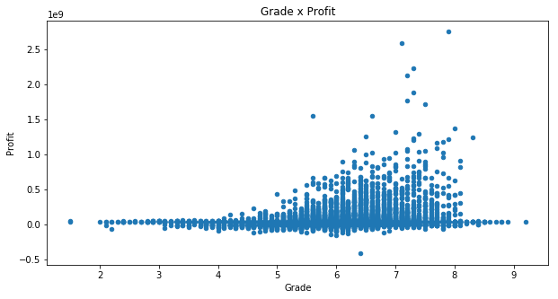

```python
# Let's try to see direclty the relationship graphically

df.plot(x='vote_average', y='profit', kind='scatter', figsize=(10,5))
plt.title('Grade x Profit')
plt.xlabel('Grade')
plt.ylabel('Profit');
```

## Conclusions

The genres that get the higher profit rates are Comedy and Drama. In general, average duration movies have more chances than short or long movies to be profitable. July and October seem more favorable to release a movie if you want to make money. Having a rating from 6 to 8 makes the movie more likely to be profitable.

### Limitations

- The TMBD Movies dataset used for our analysis may not be ehaustive: our analysis is limited to only the provided data. For example, we are not sure every movie release, from every director is listed here.
- Exchange rate or currency conversion is not taken into account here, the analysis is limited to the numerical values of revenue
- Dropping missing or Null values from variables of our interest might skew our analysis and could show unintentional bias towards the relationship being analyzed. etc.

#### Links to sources that helped me:

```
-https://stackoverflow.com/questions/26763344/convert-pandas-column-to-datetime
-https://stackoverflow.com/questions/14745022/how-to-split-a-column-into-two-columns
-https://stackoverflow.com/questions/16958499/sort-pandas-dataframe-and-print-highest-n-values
-https://stackoverflow.com/questions/25146121/extracting-just-month-and-year-separately-from-pandas-datetime-column
-https://stackoverflow.com/questions/28654047/pandas-convert-some-columns-into-rows
-https://www.geeksforgeeks.org/python-pandas-melt/
```

```python
from subprocess import call
call(['python', '-m', 'nbconvert', 'Investigate_a_Dataset.ipynb'])
```

```
0
```